# Notebook

**Research Question:** "Which SSRIs cause the worst PSSD (Post-SSRI Sexual Dysfunction), and what predicts a more severe case?"

## 1. Data Landscape

Before examining which SSRIs cause the most harm, we need to understand what the r/PSSD community looks like and how much data we have per drug. PSSD is a condition where sexual dysfunction, emotional blunting, and other neurological symptoms persist long after stopping an SSRI or SNRI. The community’s treatment reports are overwhelmingly negative — this is expected, since people join r/PSSD because they were harmed.

r/PSSD Dataset Summary

| **Data covers:** | 2026-03-12 to 2026-04-11 |
| --- | --- |
| **Total users:** | 499 |
| **Total posts:** | 2,532 |
| **Treatment reports:** | 902 |
| **Unique reporters:** | 220 |

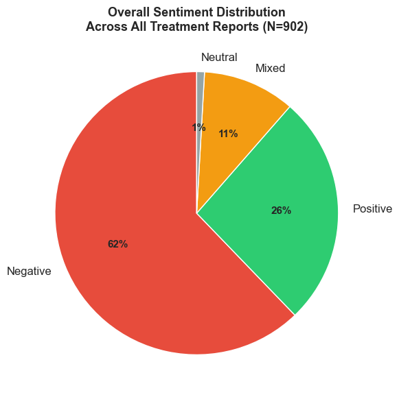

**What this means:** 62% of all treatment reports in r/PSSD carry negative sentiment. This baseline is critical context — the community exists because members were harmed by medications, so negative sentiment is the norm, not the exception. Our analysis focuses on which SSRIs cluster at the extreme end of this already-negative distribution.

## 2. Which SSRIs Are Reported as Most Harmful?

The overall picture is bleak, but not all SSRIs are reported equally. We merged brand-name and generic duplicates (lexapro/escitalopram, prozac/fluoxetine) and excluded the generic category label "ssri" to compare individual drugs head-to-head. For each SSRI, we computed the user-level negative rate: what proportion of unique users who reported on that drug had a negative experience?

SSRI Negative Outcome Rate by Drug (User-Level Aggregation)

| Drug | Users | Negative | Positive | Mixed/Neutral | Neg Rate | Pos Rate | Wilson CI Low | Wilson CI High |
| --- | --- | --- | --- | --- | --- | --- | --- | --- |
| Paroxetine | 7 | 7 | 0 | 0 | 100% | 0% | 65% | 100% |
| Sertraline | 39 | 37 | 0 | 2 | 95% | 0% | 83% | 99% |
| Vortioxetine | 8 | 7 | 0 | 1 | 88% | 0% | 53% | 98% |
| Escitalopram | 33 | 28 | 2 | 3 | 85% | 6% | 69% | 93% |
| Fluoxetine | 26 | 22 | 2 | 2 | 85% | 8% | 66% | 94% |
| Citalopram | 5 | 4 | 0 | 1 | 80% | 0% | 38% | 96% |

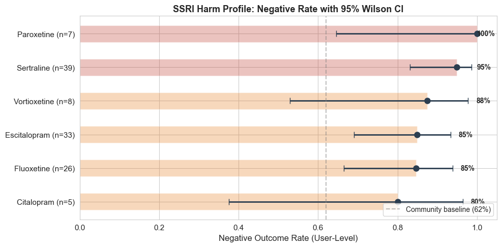

Sertraline vs Escitalopram (merged with Lexapro)

| Sertraline negative rate: | **95%** (37/39 users) |
| --- | --- |
| Escitalopram negative rate: | **85%** (28/33 users) |
| Fisher's exact p-value: | **0.2351** |
| Odds ratio: | **3.30** |
| Cohen's h: | **0.34** (small) |

**Plain language:** While sertraline shows a higher negative rate, the difference does not reach statistical significance at this sample size (p=0.235). The wide confidence intervals on escitalopram (n=33) mean we cannot reliably distinguish the two.